# HNU2000 - Session 1

## Introduction au cours HNU 2000

- tour de table
- présentation du cours
- plan des séances
- modalités d’évaluation
- ressources pour le cours

## Humanités numériques

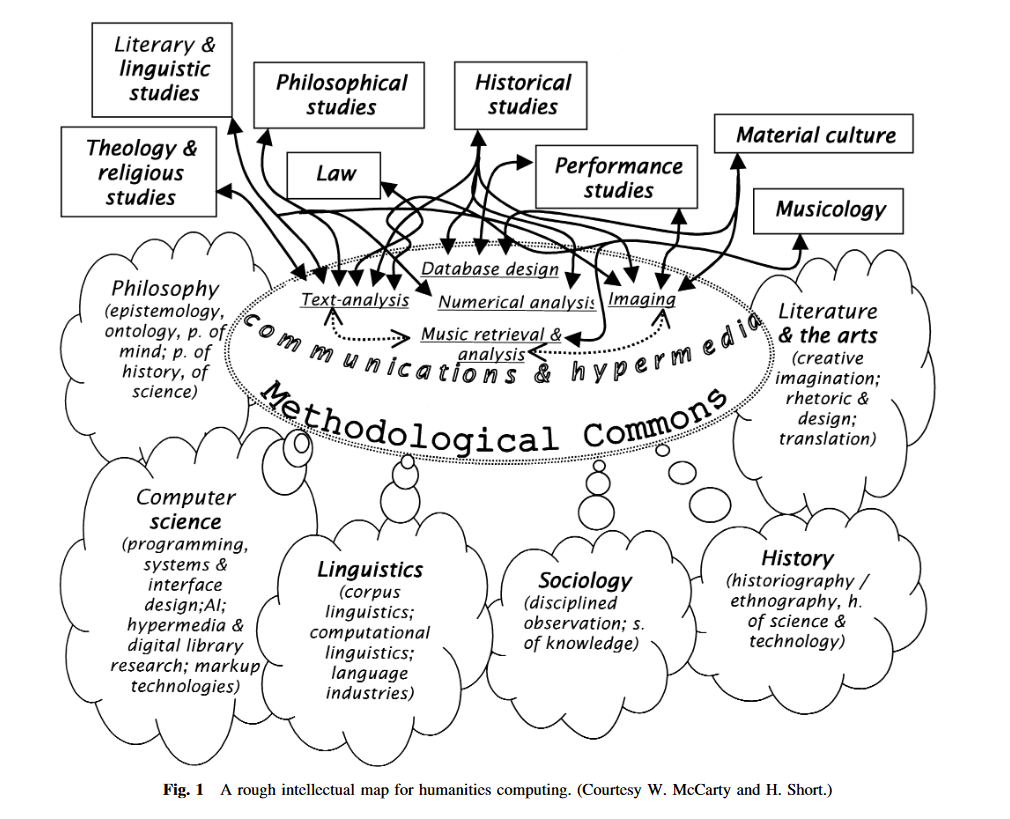

mind map of humanities computing

Willard McCarty, *Humanities Computing*, Encyclopedia of Library and Information Science (2003). [[lien vers le PDF]](https://www.mccarty.org.uk/essays/McCarty,%20Humanities%20computing.pdf)

> “”  
> Consider a rough intellectual map of humanities computing (Fig. 1). At the center of this map is a large ‘‘methodological commons’’ of computational techniques shared among the disciplines of the humanities and closely related social sciences, e.g., database design, text analysis, numerical analysis, imaging, music information retrieval, communications. Picture the disciplines ranged above the commons in groups, such as literary and linguistic studies, historical studies, material culture, musicology, performance studies, and so on. Connecting each disciplinary group to the relevant techniques are double-headed arrows indicating that these techniques are variously exported from individual fields of study into the commons and from the commons into others. The agency that sees to this import/export trade is humanities computing in its dual role as collegial service to the disciplines and as research enterprise directed to investigate their evolving methodologies, devise new computational approaches, study the effects, and tease out the implications. Below the commons are broad areas of learning that such interdisciplinary work calls on: philosophy (especially epistemology, ontology, and the philosophy of mind), historiography and ethnography, science studies, sociology of knowledge, media studies, literary criticism, linguistics, and aspects of computer science, including markup technologies, digital library research, and the language industries.  
> ““”

> “”  
> Considérons une carte intellectuelle approximative des humanités computationnelles (Fig. 1). Au centre de cette carte se trouve un vaste « fonds commun méthodologique » de techniques informatiques partagées entre les disciplines des sciences humaines et des sciences sociales étroitement liées, par exemple la conception de bases de données, l’analyse de texte, l’analyse numérique, l’imagerie, la recherche d’informations musicales, la communication. Les disciplines sont classées par groupes, tels que les études littéraires et linguistiques, les études historiques, la culture matérielle, la musicologie, les études sur les performances, etc. Des flèches à deux têtes relient chaque groupe disciplinaire aux techniques correspondantes, indiquant que ces techniques sont diversement exportées des différents domaines d’étude vers les communs et des communs vers d’autres domaines d’étude. La structure qui veille à ce commerce d’importation et d’exportation est les humanités computationelles, dans son double rôle de service collégial aux disciplines et d’entreprise de recherche chargée d’étudier l’évolution de leurs méthodologies, de concevoir de nouvelles approches informatiques, d’en étudier les effets et d’en dégager les implications. Sous les communs se trouvent de vastes domaines d’apprentissage auxquels ce travail interdisciplinaire fait appel : la philosophie (en particulier l’épistémologie, l’ontologie et la philosophie de l’esprit), l’historiographie et l’ethnographie, les études scientifiques, la sociologie de la connaissance, les études sur les médias, la critique littéraire, la linguistique et certains aspects de l’informatique, y compris les technologies de balisage, la recherche sur les bibliothèques numériques et les industries de la langue.  
> ““”